# Presentación

Teoría de la Computación  
2026-2

Walter Quispe Vargas

wquispev@utec.edu.pe  
Departamento de Ciencia de la Computación, UTEC

## Introducción

- ¿Cuáles son las capacidades y limitaciones fundamentales de las computadoras?
  - Que pueden hacer (qué problemas pueden resolverse mediante procedimientos computacionales).
  - Cómo lo hacen (cuánto tiempo y memoria se requiere para resolver problemas).
  - Cuáles son sus límites fundamentales.

## Introducción

- La Teoría de la Computación es el estudio FORMAL y ABSTRACTO de las **COMPUTADORAS**.
- Historia: Concepto de **Computación** por [Alan Turing](https://gradschool.princeton.edu/about/viget-honor-roll/alan-mathison-turing) y Alonzo Church, 1930.
- Actualidad: Avances científicos y tecnológicos an incrementado nuestra capacidad de `computar` (IA, Computación de alto rendimiento, computación cuántica).
- [VERITASIUM: Las Matemáticas Tienen Una FALLA Descomunal](https://www.youtube.com/watch?v=RRg38oNQ9vk) (Attention! … is all you need :) - min:22)

## Teoaría de la Computación

- Areas: `Autómatas, Computabilidad y Complejidad`
- `Autómatas`: Modelos matemáticos de máquinas abstractas. Se estudia los problemas que pueden resolver.
  - Autómatas finitos, Autómatas con pila (memoria), Máquinas de Turing.
- `Computabilidad`: Examina qué problemas pueden ser resueltos por las computadoras y cuáles no.
  - Problemas Decidibles: Problemas para los cuales existe un algoritmo que puede determinar la solución en un tiempo finito.
  - Problemas Indecidibles: Problemas para los cuales no existe un algoritmo que pueda determinar la solución para todos los casos posibles.
- `Complejidad`: Clasifica los problemas según los recursos computacionales necesarios para resolverlos (tiempo y espacio).
  - **P (Tiempo Polinómico)**: Conjunto de problemas que pueden ser resueltos por una máquina de Turing determinista en tiempo polinómico. Representa los problemas que son “fácilmente” solucionables.
  - **NP (Tiempo No Determinista Polinómico)**: Conjunto de problemas cuyas soluciones pueden ser verificadas por una máquina de Turing determinista en tiempo polinómico. Incluye problemas que pueden no ser fácilmente solucionables, pero cuyas soluciones pueden ser verificadas rápidamente.
  - El problema del Milenio $P \neq NP$ https://www.claymath.org/millennium/p-vs-np/

## Competencias

- ABET-COM-01 Analizar un problema computacional complejo y aplicar principios de computación y otras disciplinas relevantes para identificar soluciones.
- ABET-COM-03 Comunicarse eficazmente en una variedad de contextos profesionales.
- ABET-CCS-06 Aplicar la teoría de la ciencia de la computación y los fundamentos de desarrollo de software para producir soluciones basadas en computación. [CS]

## Resultados de Aprendizaje

- RA1 Analizar problemas de pertenencia de un lenguaje a una clase de lenguajes usando métodos de Teoría de la Computación.
- RA2 Demostrar la habilidad de justificación escrita realizando demostraciones usando conceptos de Teoría de la Computación.
- RA3 Producir modelos que resuelvan los problemas de diferentes tipos de lenguajes.

## Contenido

- Autómatas finitos y Lenguajes regulares
  1. Autómatas Finitos Deterministas (AFD).
  2. Autómatas Finitos No Deterministas (AFN).
  3. Expresiones regulares.
  4. Lema de bombeo.

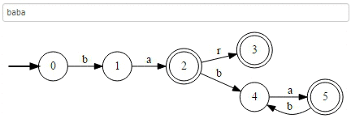

## Contenido

- Lenguajes Independientes de Contexto
  1. Gramáticas independientes del contexto.
  2. Autómatas con Pila.
  3. Ambigüedad.
  4. Lema de bombeo.

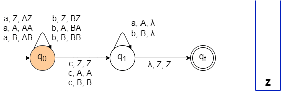

## Contenido

- Máquinas de Turing y Computabilidad
  1. Máquinas de Turing.
  2. Lenguajes reconocibles y decidibles.
  3. Problema de la Parada.
  4. Reducciones.

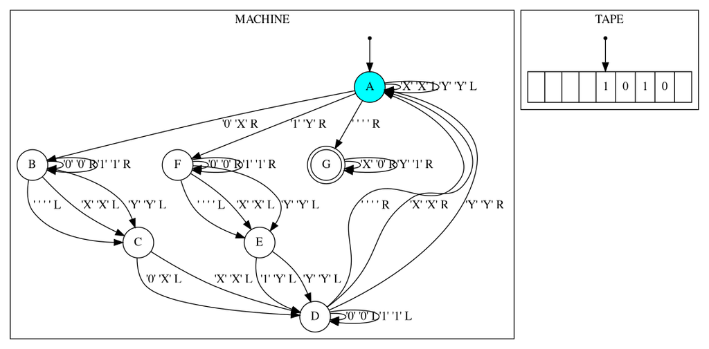

## Contenido

- Tratabilidad (Complejidad)
  1. Las clases P y NP.
  2. NP completitud.
  3. Reducciones polinomiales.

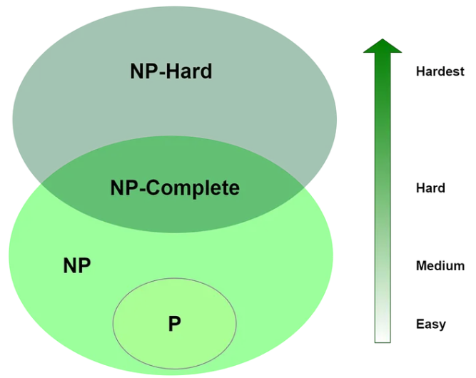

## Bibliografia

[figure not shown]

## Herramientas

- https://pypi.org/project/automata-lib/
- https://www.jflap.org

## Sistema de Evaluación

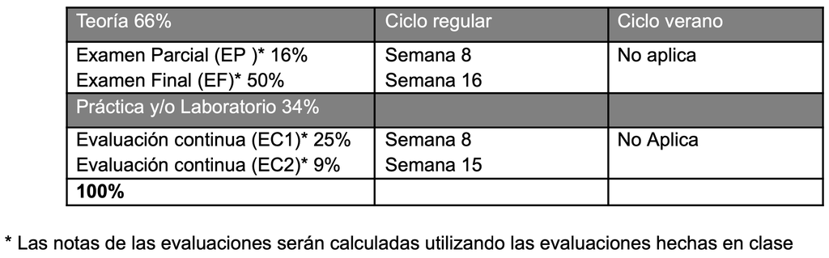